# Expansión de la CASEN sobre el CENSO (Región 01 Urbano)

P17 ¿Trabajó por un pago o especie?: Correlación: 0.8717

VE-CC-AJ

DataIntelligence

date: 10-08-2021

# 1 Introducción

Haremos el análisis sobre las 16 regiones y en el ambiente urbano.

Ensayaremos diferentes modelos dentro del análisis de regresión cuya variable independiente será: “frecuencia de población que posee la variable Censal respecto a la zona” y la dependiente: “ingreso expandido por zona por proporción zonal a nivel comunal (**multipob**)”

Lo anterior para elegir el que posea el mayor coeficiente de determinación y así contruir una tabla de valores predichos.

## 1.1 Criterios de exclusión. Son los motivos por los cuales cartográficamente no figura información zonal. Hemos determinado 4 causas:

0. Que no existan en la base de datos original shp (**pseudocriterio**).
1. Que en la zona en cuestión no exista la respuesta a la pregunta indagada. Error I
2. Que no existan datos de ingreso comunal Casen para la zona. Error II
3. Que se excluyan registros zonales con el criterio <1.5*IQR >1.5*IQR sobre frecuencias. Error III
4. Que se excluyan registros zonales con el criterio <1.5*IQR >1.5*IQR sobre los ingresos medios zona. Error IV

En éste trabajo sólo excluiremos, en uno futuro reemplazaremos.

# 2 Variable CENSO

Necesitamos calcular las frecuencias a nivel censal de las respuestas correspondientes a la categoría: “Trabajó por un pago o especie” del campo **P17** del Censo de personas. Recordemos que ésta fué la más alta correlación en relación a los ingresos expandidos [(ver punto 2 Correlaciones aquí)](https://rpubs.com/dataintelligence/corr_ce_ca_P17).

## 2.1 Lectura y filtrado de la tabla censal de personas

Leemos la tabla Censo 2017 de personas que ya tiene integrada la clave zonal:

```r
tabla_con_clave_o <-
readRDS("C:\\Users\\chris\\OneDrive\\Documentos\\GitHub\\ds_correlaciones_censo_casen\\corre_censo_casen_2017\\censos_con_clave\\censo_personas_con_clave_17")
abc <- tabla_con_clave_o[c(1:100),]
kbl(abc) %>%
  kable_styling(bootstrap_options = c("striped", "hover")) %>%
  kable_paper() %>%
  scroll_box(width = "100%", height = "300px")
```

| REGION | PROVINCIA | COMUNA | DC | AREA | ZC_LOC | ID_ZONA_LOC | NVIV | NHOGAR | PERSONAN | P07 | P08 | P09 | P10 | P10COMUNA | P10PAIS | P11 | P11COMUNA | P11PAIS | P12 | P12COMUNA | P12PAIS | P12A_LLEGADA | P12A_TRAMO | P13 | P14 | P15 | P15A | P16 | P16A | … |
| --- | --- | --- | --- | --- | --- | --- | --- | --- | --- | --- | --- | --- | --- | --- | --- | --- | --- | --- | --- | --- | --- | --- | --- | --- | --- | --- | --- | --- | --- | --- |
| 15 | 152 | 15202 | 1 | 2 | 6 | 13225 | 1 | 1 | 1 | 1 | 1 | 73 | 1 | 98 | 998 | 3 | 15101 | 998 | 1 | 98 | 998 | 9998 | 98 | 2 | 4 | 6 | 2 | 1 | 2 | … |
| 15 | 152 | 15202 | 1 | 2 | 6 | 13225 | 3 | 1 | 1 | 1 | 1 | 78 | 1 | 98 | 998 | 2 | 98 | 998 | 1 | 98 | 998 | 9998 | 98 | 3 | 98 | 98 | 98 | 1 | 2 | … |
| 15 | 152 | 15202 | 1 | 2 | 6 | 13225 | 3 | 1 | 2 | 2 | 2 | 78 | 1 | 98 | 998 | 2 | 98 | 998 | 1 | 98 | 998 | 9998 | 98 | 3 | 98 | 98 | 98 | 1 | 2 | … |
| 15 | 152 | 15202 | 1 | 2 | 6 | 13225 | 3 | 1 | 3 | 5 | 2 | 52 | 1 | 98 | 998 | 2 | 98 | 998 | 1 | 98 | 998 | 9998 | 98 | 1 | 2 | 5 | 2 | 1 | 2 | … |
| 15 | 152 | 15202 | 1 | 2 | 6 | 13225 | 3 | 1 | 4 | 11 | 1 | 44 | 1 | 98 | 998 | 2 | 98 | 998 | 1 | 98 | 998 | 9998 | 98 | 1 | 3 | 5 | 2 | 1 | 2 | … |
| 15 | 152 | 15202 | 1 | 2 | 6 | 13225 | 9 | 1 | 1 | 1 | 1 | 39 | 1 | 98 | 998 | 2 | 98 | 998 | 1 | 98 | 998 | 9998 | 98 | 2 | 8 | 5 | 1 | 1 | 2 | … |
| 15 | 152 | 15202 | 1 | 2 | 6 | 13225 | 9 | 1 | 2 | 2 | 2 | 35 | 1 | 98 | 998 | 2 | 98 | 998 | 1 | 98 | 998 | 9998 | 98 | 2 | 6 | 5 | 2 | 1 | 2 | … |
| 15 | 152 | 15202 | 1 | 2 | 6 | 13225 | 9 | 1 | 3 | 5 | 1 | 13 | 1 | 98 | 998 | 2 | 98 | 998 | 1 | 98 | 998 | 9998 | 98 | 1 | 7 | 5 | 2 | 1 | 2 | … |
| 15 | 152 | 15202 | 1 | 2 | 6 | 13225 | 9 | 1 | 4 | 5 | 1 | 12 | 1 | 98 | 998 | 2 | 98 | 998 | 1 | 98 | 998 | 9998 | 98 | 1 | 6 | 5 | 2 | 1 | 2 | … |
| 15 | 152 | 15202 | 1 | 2 | 6 | 13225 | 10 | 1 | 1 | 1 | 2 | 65 | 1 | 98 | 998 | 2 | 98 | 998 | 1 | 98 | 998 | 9998 | 98 | 2 | 4 | 5 | 2 | 1 | 2 | … |
| 15 | 152 | 15202 | 1 | 2 | 6 | 13225 | 13 | 1 | 1 | 1 | 1 | 50 | 1 | 98 | 998 | 2 | 98 | 998 | 1 | 98 | 998 | 9998 | 98 | 2 | 5 | 5 | 2 | 1 | 2 | … |
| 15 | 152 | 15202 | 1 | 2 | 6 | 13225 | 13 | 1 | 2 | 4 | 2 | 43 | 1 | 98 | 998 | 2 | 98 | 998 | 1 | 98 | 998 | 9998 | 98 | 2 | 6 | 5 | 2 | 1 | 2 | … |
| 15 | 152 | 15202 | 1 | 2 | 6 | 13225 | 13 | 1 | 3 | 5 | 1 | 15 | 3 | 15201 | 998 | 2 | 98 | 998 | 1 | 98 | 998 | 9998 | 98 | 1 | 1 | 7 | 2 | 1 | 2 | … |
| 15 | 152 | 15202 | 1 | 2 | 6 | 13225 | 16 | 1 | 1 | 1 | 1 | 75 | 1 | 98 | 998 | 2 | 98 | 998 | 1 | 98 | 998 | 9998 | 98 | 3 | 98 | 98 | 98 | 1 | 2 | … |
| 15 | 152 | 15202 | 1 | 2 | 6 | 13225 | 16 | 1 | 2 | 16 | 2 | 58 | 4 | 98 | 68 | 6 | 98 | 998 | 5 | 98 | 998 | 9999 | 1 | 3 | 98 | 98 | 98 | 1 | 2 | … |
| 15 | 152 | 15202 | 1 | 2 | 6 | 13225 | 16 | 1 | 3 | 2 | 2 | 70 | 1 | 98 | 998 | 2 | 98 | 998 | 1 | 98 | 998 | 9998 | 98 | 3 | 98 | 98 | 98 | 1 | 2 | … |
| 15 | 152 | 15202 | 1 | 2 | 6 | 13225 | 17 | 1 | 1 | 1 | 2 | 43 | 2 | 98 | 998 | 2 | 98 | 998 | 1 | 98 | 998 | 9998 | 98 | 2 | 8 | 5 | 1 | 1 | 2 | … |
| 15 | 152 | 15202 | 1 | 2 | 6 | 13225 | 17 | 1 | 2 | 4 | 1 | 55 | 2 | 98 | 998 | 2 | 98 | 998 | 1 | 98 | 998 | 9998 | 98 | 2 | 6 | 5 | 2 | 1 | 2 | … |
| 15 | 152 | 15202 | 1 | 2 | 6 | 13225 | 17 | 1 | 3 | 5 | 2 | 13 | 2 | 98 | 998 | 2 | 98 | 998 | 2 | 15101 | 998 | 9998 | 98 | 1 | 7 | 5 | 2 | 1 | 2 | … |
| 15 | 152 | 15202 | 1 | 2 | 6 | 13225 | 17 | 1 | 4 | 5 | 1 | 8 | 2 | 98 | 998 | 2 | 98 | 998 | 2 | 15101 | 998 | 9998 | 98 | 1 | 2 | 5 | 2 | 1 | 2 | … |
| 15 | 152 | 15202 | 1 | 2 | 6 | 13225 | 17 | 1 | 5 | 15 | 2 | 29 | 2 | 98 | 998 | 4 | 98 | 998 | 3 | 98 | 998 | 2015 | 1 | 2 | 6 | 5 | 2 | 1 | 2 | … |
| 15 | 152 | 15202 | 1 | 2 | 6 | 13225 | 17 | 1 | 6 | 15 | 1 | 4 | 2 | 98 | 998 | 1 | 98 | 998 | 5 | 98 | 998 | 2015 | 1 | 1 | 0 | 1 | 2 | 1 | 2 | … |
| 15 | 152 | 15202 | 1 | 2 | 6 | 13225 | 17 | 1 | 7 | 15 | 2 | 2 | 2 | 98 | 998 | 1 | 98 | 998 | 3 | 98 | 998 | 2015 | 1 | 1 | 0 | 1 | 2 | 1 | 2 | … |
| 15 | 152 | 15202 | 1 | 2 | 6 | 13225 | 17 | 1 | 8 | 15 | 1 | 16 | 2 | 98 | 998 | 6 | 98 | 998 | 1 | 98 | 998 | 9998 | 98 | 2 | 4 | 5 | 2 | 1 | 2 | … |
| 15 | 152 | 15202 | 1 | 2 | 6 | 13225 | 18 | 1 | 1 | 1 | 2 | 74 | 1 | 98 | 998 | 2 | 98 | 998 | 1 | 98 | 998 | 9998 | 98 | 2 | 2 | 5 | 2 | 1 | 2 | … |
| 15 | 152 | 15202 | 1 | 2 | 6 | 13225 | 19 | 1 | 1 | 1 | 1 | 68 | 1 | 98 | 998 | 2 | 98 | 998 | 1 | 98 | 998 | 9998 | 98 | 3 | 98 | 98 | 98 | 1 | 2 | … |
| 15 | 152 | 15202 | 1 | 2 | 6 | 13225 | 20 | 1 | 1 | 1 | 1 | 74 | 1 | 98 | 998 | 3 | 15101 | 998 | 1 | 98 | 998 | 9998 | 98 | 2 | 2 | 5 | 2 | 1 | 2 | … |
| 15 | 152 | 15202 | 1 | 2 | 6 | 13225 | 20 | 1 | 2 | 2 | 2 | 65 | 1 | 98 | 998 | 3 | 997 | 998 | 3 | 98 | 998 | 9999 | 2 | 2 | 2 | 5 | 2 | 1 | 2 | … |
| 15 | 152 | 15202 | 1 | 2 | 6 | 13225 | 25 | 1 | 1 | 1 | 2 | 76 | 1 | 98 | 998 | 2 | 98 | 998 | 1 | 98 | 998 | 9998 | 98 | 3 | 98 | 98 | 98 | 1 | 2 | … |
| 15 | 152 | 15202 | 1 | 2 | 6 | 13225 | 25 | 1 | 2 | 5 | 2 | 36 | 1 | 98 | 998 | 2 | 98 | 998 | 1 | 98 | 998 | 9998 | 98 | 2 | 4 | 8 | 1 | 1 | 2 | … |

[output cut: 70 more lines]

## 2.2 Necesitamos una tabla que relacione claves zonales con codigos comunales:

```r
tabla_clave_comuna <- tabla_con_clave_o %>% distinct(clave, .keep_all = TRUE)
tabla_clave_comuna <- tabla_clave_comuna[,-c(1:2,4:48), drop=FALSE]
codigos <- tabla_clave_comuna$COMUNA
rango <- seq(1:nrow(tabla_clave_comuna))
cadena <- paste("0",codigos[rango], sep = "")
cadena <- substr(cadena,(nchar(cadena)[rango])-(4),6)
codigos <- as.data.frame(codigos)
cadena <- as.data.frame(cadena)
comuna_corr <- cbind(tabla_clave_comuna,cadena)
comuna_corr <- comuna_corr[,-(1)]
names(comuna_corr)[2] <- "código"
head(comuna_corr,10)
```

```
##          clave código
## 1  15202012006  15202
## 2  15202012008  15202
## 3  15202012012  15202
## 4  15202012015  15202
## 5  15202022004  15202
## 6  15202022005  15202
## 7  15202022009  15202
## 8  15202022011  15202
## 9  15202022901  15202
## 10 15202032001  15202
```

## 2.3 Leemos la tabla shp original que contempla 221 zonas más.

```r
archivo_shp <- read_sf("../shp/lim_ZONLOC_codigos.shp")
head(data.frame(archivo_shp),10)
```

```
##     COD_ZonLoc   Geocodigo                       geometry
## 1  10101011001 10101011001 MULTIPOLYGON (((-72.94394 -...
## 2  10101011002 10101011002 MULTIPOLYGON (((-72.92106 -...
## 3  10101021001 10101021001 MULTIPOLYGON (((-72.9591 -4...
## 4  10101021002 10101021002 MULTIPOLYGON (((-72.95028 -...
## 5  10101021003 10101021003 MULTIPOLYGON (((-72.95514 -...
## 6  10101021004 10101021004 MULTIPOLYGON (((-72.95628 -...
## 7  10101021005 10101021005 MULTIPOLYGON (((-72.96549 -...
## 8  10101031001 10101031001 MULTIPOLYGON (((-72.96078 -...
## 9  10101031002 10101031002 MULTIPOLYGON (((-72.96557 -...
## 10 10101031003 10101031003 MULTIPOLYGON (((-72.96938 -...
```

```r
nrow(archivo_shp)
```

```
## [1] 15721
```

# 3 Análisis de zonas Región 1

## 3.1 Zonas totales

```r
fyt <- filter(tabla_con_clave_o, tabla_con_clave_o$AREA == 1 || tabla_con_clave_o$AREA == 2)
fyt2 <- filter(fyt, fyt$REGION == 1)
fyt3 <- filter(fyt2, fyt2$P09 > 15)
f_zona_urbana_y_rural <- unique(fyt3$clave)
length(f_zona_urbana_y_rural)
```

```
## [1] 199
```

## 3.2 Zonas totales urbanas

```r
fyt <- filter(tabla_con_clave_o, tabla_con_clave_o$AREA == 1)
fyt22 <- filter(fyt, fyt$REGION ==1)
fyt33 <- filter(fyt22, fyt22$P09 > 15)
f_zona_urbana <- unique(fyt33$clave)
length(f_zona_urbana)
```

```
## [1] 86
```

## 3.3 Zonas totales rurales

```r
fyt <- filter(tabla_con_clave_o, tabla_con_clave_o$AREA == 2)
fyt222 <- filter(fyt, fyt$REGION == 1)
fyt333 <- filter(fyt222, fyt222$P09 > 15)
f_zona_rural <- unique(fyt333$clave)
length(f_zona_rural)
```

```
## [1] 113
```

Somos responsables de 86 registros que cumplen el criterio AREA == 1, REGION ==1, P09 > 15):

```r
length(f_zona_urbana)
```

```
## [1] 86
```

## 3.4 Verificación criterio 2:

Aplicamos todos nuestros filtros a la tabla Censal original:

```r
fyt <- filter(tabla_con_clave_o, tabla_con_clave_o$AREA == 1)
fyt22 <- filter(fyt, fyt$REGION ==1)
fyt33 <- filter(fyt22, fyt22$P09 > 15)
tabla_con_clave_f <- filter(fyt33,fyt33$P17 == 1)
tabla_con_clave_f  <- as.data.frame(tabla_con_clave_f)
tabla_con_clave_f <-tabla_con_clave_f[,-c(2,4,6:31,33:48), drop=FALSE]
tabla_con_clave_f <- as.data.frame(tabla_con_clave_f)
f_zona_urbana <- unique(tabla_con_clave_f$clave)
length(f_zona_urbana)
```

```
## [1] 86
```

**I** Obtenemos **todos** los registros urbanos de la tabla original, por lo que no hay problemas de exclusión con el Error I

## 3.5 Cálculo de frecuencias a la pregunta P17

```r
e <- xtabs(~clave+P17, data=tabla_con_clave_f)
e <- as.data.frame(e)
head(e,10)
```

```
##         clave P17 Freq
## 1  1101011001   1 1255
## 2  1101011002   1  621
## 3  1101021001   1  493
## 4  1101021002   1   33
## 5  1101021003   1 1224
## 6  1101021004   1  968
## 7  1101021005   1 1927
## 8  1101031001   1 1179
## 9  1101031002   1 1582
## 10 1101031003   1 2111
```

### 3.5.1 Unir los codigos comunales correctos a las frecuencias

```r
tabla_1 = merge( x = e, y = comuna_corr, by = "clave", all.x = TRUE)
head(tabla_1,10)
```

```
##         clave P17 Freq código
## 1  1101011001   1 1255  01101
## 2  1101011002   1  621  01101
## 3  1101021001   1  493  01101
## 4  1101021002   1   33  01101
## 5  1101021003   1 1224  01101
## 6  1101021004   1  968  01101
## 7  1101021005   1 1927  01101
## 8  1101031001   1 1179  01101
## 9  1101031002   1 1582  01101
## 10 1101031003   1 2111  01101
```

### 3.5.2 Unimos ingresos expandidos con frecuencias

```r
tabla_1 <- data.frame(lapply(tabla_1, as.character), stringsAsFactors=FALSE)
ingresos_expandidos_urbanos <- readRDS("ingresos_expandidos_casen_2017_totales_u.rds")
tabla_3 = merge( x =  tabla_1 , y = ingresos_expandidos_urbanos, by = "código", all.x = TRUE)
names(tabla_3)[2] <- "zona"
names(tabla_3)[5] <- "comuna"
names(tabla_3)[6] <- "tipo"
tabla_3$zona <- as.character(tabla_3$zona)
head(tabla_3,10)
```

```
##    código       zona P17 Freq  comuna   tipo promedio_i  año personas
## 1   01101 1101021001   1  493 Iquique Urbano   356487.6 2017   191468
## 2   01101 1101021002   1   33 Iquique Urbano   356487.6 2017   191468
## 3   01101 1101011001   1 1255 Iquique Urbano   356487.6 2017   191468
## 4   01101 1101011002   1  621 Iquique Urbano   356487.6 2017   191468
## 5   01101 1101021005   1 1927 Iquique Urbano   356487.6 2017   191468
## 6   01101 1101031001   1 1179 Iquique Urbano   356487.6 2017   191468
## 7   01101 1101031002   1 1582 Iquique Urbano   356487.6 2017   191468
## 8   01101 1101031003   1 2111 Iquique Urbano   356487.6 2017   191468
## 9   01101 1101031004   1 1532 Iquique Urbano   356487.6 2017   191468
## 10  01101 1101041001   1  712 Iquique Urbano   356487.6 2017   191468
##    Ingresos_expandidos
## 1          68255976664
## 2          68255976664
## 3          68255976664
## 4          68255976664
## 5          68255976664
## 6          68255976664
## 7          68255976664
## 8          68255976664
## 9          68255976664
## 10         68255976664
```

### 3.5.3 hay que integrar las proporciones poblacionales zonales

```r
tabla_de_prop_pob <- readRDS("tabla_de_prop_pob.rds")
names(tabla_de_prop_pob)[1] <- "zona"
tabla_de_prop_pob$zona <- as.character(tabla_de_prop_pob$zona)
tabla_4 = merge( x = tabla_3, y = tabla_de_prop_pob, by = "zona", all.x = TRUE)
names(tabla_4)[4] <- "frecuencia"
tabla_5 <- tabla_4[, -c( 11,13)]
head(tabla_5,10)
```

```
##          zona código.x P17 frecuencia  comuna   tipo promedio_i  año personas
## 1  1101011001    01101   1       1255 Iquique Urbano   356487.6 2017   191468
## 2  1101011002    01101   1        621 Iquique Urbano   356487.6 2017   191468
## 3  1101021001    01101   1        493 Iquique Urbano   356487.6 2017   191468
## 4  1101021002    01101   1         33 Iquique Urbano   356487.6 2017   191468
## 5  1101021003    01101   1       1224 Iquique Urbano   356487.6 2017   191468
## 6  1101021004    01101   1        968 Iquique Urbano   356487.6 2017   191468
## 7  1101021005    01101   1       1927 Iquique Urbano   356487.6 2017   191468
## 8  1101031001    01101   1       1179 Iquique Urbano   356487.6 2017   191468
## 9  1101031002    01101   1       1582 Iquique Urbano   356487.6 2017   191468
## 10 1101031003    01101   1       2111 Iquique Urbano   356487.6 2017   191468
##    Ingresos_expandidos            p
## 1          68255976664 0.0130100069
## 2          68255976664 0.0077036372
## 3          68255976664 0.0052384733
## 4          68255976664 0.0002820315
## 5          68255976664 0.0151200201
## 6          68255976664 0.0125242860
## 7          68255976664 0.0236331920
## 8          68255976664 0.0142321432
## 9          68255976664 0.0185618485
## 10         68255976664 0.0273988343
```

### 3.5.4 Construir multipob

#### 3.5.4.1 Verificación criterio 3:

```r
tabla_5$multipob <- tabla_5$Ingresos_expandidos*tabla_5$p
sum(is.na(tabla_5$promedio_i))
```

```
## [1] 2
```

**2** Perdemos dos registros por el Error II.

```r
frec_sin <- subset(tabla_5,!is.na(promedio_i))
```

Como sabemos cuales son?

```r
frec_con <- subset(tabla_5,is.na(promedio_i))
frec_con
```

```
##          zona código.x P17 frecuencia comuna tipo promedio_i  año personas
## 83 1404011001    01404   1        448   <NA> <NA>         NA <NA>       NA
## 84 1404991999    01404   1         21   <NA> <NA>         NA <NA>       NA
##    Ingresos_expandidos          p multipob
## 83                  NA 0.39633700       NA
## 84                  NA 0.00989011       NA
```

Corroboramos la exclusión de los dos registros:

```r
nrow(frec_sin)
```

```
## [1] 84
```

# 4 Análisis de regresión CON OUTLIERS

Aplicaremos un análisis de regresión donde:

$$Y(dependiente) = ingreso \ expandido \ por \ zona \ (multi\_pob)$$

$$X(independiente) = frecuencia \ de \ población \ que \ posee \ la \ variable \ Censal \ respecto \ a \ la \ zona \ (Freq.x)$$

## 4.1 Modelo lineal

Aplicaremos un análisis de regresión lineal del ingreso expandido por zona sobre las frecuencias de respuestas zonales.

```r
frec_sin$frecuencia <- as.numeric(frec_sin$frecuencia)
linearMod <- lm( multipob~(frecuencia) , data=frec_sin)
summary(linearMod)
```

```
##
## Call:
## lm(formula = multipob ~ (frecuencia), data = frec_sin)
##
## Residuals:
##        Min         1Q     Median         3Q        Max
## -315501962  -49447152   16823609   59843648  177323100
##
## Coefficients:
##              Estimate Std. Error t value Pr(>|t|)
## (Intercept) -46244637   27223954  -1.699   0.0932 .
## frecuencia     823807      16363  50.344   <2e-16 ***
## ---
## Signif. codes:  0 '***' 0.001 '**' 0.01 '*' 0.05 '.' 0.1 ' ' 1
##
## Residual standard error: 88900000 on 82 degrees of freedom
## Multiple R-squared:  0.9687, Adjusted R-squared:  0.9683
## F-statistic:  2535 on 1 and 82 DF,  p-value: < 2.2e-16
```

### 4.1.1 Gráfica de la recta de regresión lineal

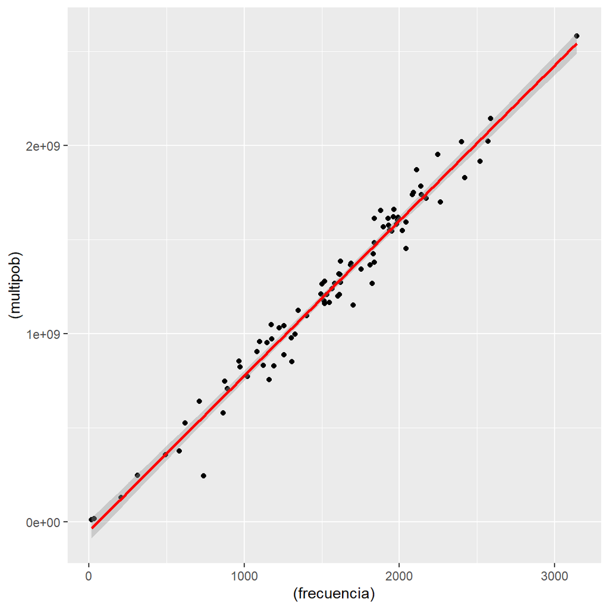

```r
ggplot(frec_sin, aes(x = (frecuencia), y = (multipob))) +
  geom_point() +
  stat_smooth(method = "lm", col = "red")
```

### 4.1.2 Modelos alternativos

```r
### 8.1 Modelo cuadrático

linearMod <- lm( multipob~(frecuencia^2) , data=frec_sin)
datos <- summary(linearMod)
dato <- datos$adj.r.squared
modelo <- "cuadrático"
sintaxis <- "linearMod <- lm( multi_pob~(Freq.x^2) , data=h_y_m_comuna_corr_01)"

modelos1 <- cbind(modelo,dato,sintaxis)


modelos1 <- cbind(modelo,dato,sintaxis)

### 8.2 Modelo cúbico

linearMod <- lm( multipob~(frecuencia^3) , data=frec_sin)
datos <- summary(linearMod)
dato <- datos$adj.r.squared
modelo <- "cúbico"
sintaxis <- "linearMod <- lm( multi_pob~(Freq.x^3) , data=h_y_m_comuna_corr_01)"

modelos2 <- cbind(modelo,dato,sintaxis)

### 8.3 Modelo logarítmico

linearMod <- lm( multipob~log(frecuencia) , data=frec_sin)
datos <- summary(linearMod)
dato <- datos$adj.r.squared
modelo <- "logarítmico"
sintaxis <- "linearMod <- lm( multi_pob~log(Freq.x) , data=h_y_m_comuna_corr_01)"

modelos3 <- cbind(modelo,dato,sintaxis)

### 8.5 Modelo con raíz cuadrada

linearMod <- lm( multipob~sqrt(frecuencia) , data=frec_sin)
datos <- summary(linearMod)
dato <- datos$adj.r.squared
modelo <- "raíz cuadrada"
sintaxis <- "linearMod <- lm( multi_pob~sqrt(Freq.x) , data=h_y_m_comuna_corr_01)"

modelos5 <- cbind(modelo,dato,sintaxis)

### 8.6 Modelo raíz-raíz

linearMod <- lm( sqrt(multipob)~sqrt(frecuencia) , data=frec_sin)
datos <- summary(linearMod)
dato <- datos$adj.r.squared
modelo <- "raíz-raíz"
sintaxis <- "linearMod <- lm( sqrt(multi_pob)~sqrt(Freq.x) , data=h_y_m_comuna_corr_01)"

modelos6 <- cbind(modelo,dato,sintaxis)

### 8.7 Modelo log-raíz

linearMod <- lm( log(multipob)~sqrt(frecuencia) , data=frec_sin)
datos <- summary(linearMod)
dato <- datos$adj.r.squared
modelo <- "log-raíz"
sintaxis <- "linearMod <- lm( log(multi_pob)~sqrt(Freq.x) , data=h_y_m_comuna_corr_01)"

modelos7 <- cbind(modelo,dato,sintaxis)

### 8.8 Modelo raíz-log

linearMod <- lm( sqrt(multipob)~log(frecuencia) , data=frec_sin)
datos <- summary(linearMod)
dato <- datos$adj.r.squared
modelo <- "raíz-log"
sintaxis <- "linearMod <- lm( sqrt(multi_pob)~log(Freq.x) , data=h_y_m_comuna_corr_01)"

modelos8 <- cbind(modelo,dato,sintaxis)

### 8.9 Modelo log-log

linearMod <- lm( log(multipob)~log(frecuencia) , data=frec_sin)
datos <- summary(linearMod)
dato <- datos$adj.r.squared
modelo <- "log-log"
sintaxis <- "linearMod <- lm( log(multi_pob)~log(Freq.x) , data=h_y_m_comuna_corr_01)"

modelos9 <- cbind(modelo,dato,sintaxis)

modelos_bind <- rbind(modelos1, modelos2,modelos3,modelos5,modelos6,modelos7,modelos8,modelos9)
modelos_bind <- as.data.frame(modelos_bind)

modelos_bind <<- modelos_bind[order(modelos_bind$dato, decreasing = T ),]

#h_y_m_comuna_corr_01 <<- comunas_censo_casen

kbl(modelos_bind) %>%
  kable_styling(bootstrap_options = c("striped", "hover")) %>%
  kable_paper() %>%
  scroll_box(width = "100%", height = "400px")
```

|  | modelo | dato | sintaxis |
| --- | --- | --- | --- |
| 8 | log-log | 0.97989629522072 | linearMod <- lm( log(multi_pob)~log(Freq.x) , data=h_y_m_comuna_corr_01) |
| 5 | raíz-raíz | 0.970322106713924 | linearMod <- lm( sqrt(multi_pob)~sqrt(Freq.x) , data=h_y_m_comuna_corr_01) |
| 1 | cuadrático | 0.968279027105152 | linearMod <- lm( multi_pob~(Freq.x^2) , data=h_y_m_comuna_corr_01) |
| 2 | cúbico | 0.968279027105152 | linearMod <- lm( multi_pob~(Freq.x^3) , data=h_y_m_comuna_corr_01) |
| 4 | raíz cuadrada | 0.906187228583836 | linearMod <- lm( multi_pob~sqrt(Freq.x) , data=h_y_m_comuna_corr_01) |
| 6 | log-raíz | 0.859772208419047 | linearMod <- lm( log(multi_pob)~sqrt(Freq.x) , data=h_y_m_comuna_corr_01) |
| 7 | raíz-log | 0.832839000077064 | linearMod <- lm( sqrt(multi_pob)~log(Freq.x) , data=h_y_m_comuna_corr_01) |
| 3 | logarítmico | 0.645781469772034 | linearMod <- lm( multi_pob~log(Freq.x) , data=h_y_m_comuna_corr_01) |

### 4.1.3 Elección del modelo.

Elegimos el modelo log-log (8) pues tiene el más alto $R^2$

```r
metodo <-8
switch (metodo,
        case = linearMod <- lm( multipob~(frecuencia^2) , data=frec_sin),
        case = linearMod <- lm( multipob~(frecuencia^3) , data=frec_sin),
        case = linearMod <- lm( multipob~log(frecuencia) , data=frec_sin),
        case = linearMod <- lm( multipob~sqrt(frecuencia) , data=frec_sin),
        case = linearMod <- lm( sqrt(multipob)~sqrt(frecuencia) , data=frec_sin),
        case = linearMod <- lm( log(multipob)~sqrt(frecuencia) , data=frec_sin),
        case = linearMod <- lm( sqrt(multipob)~log(frecuencia) , data=frec_sin),
        case = linearMod <- lm( log(multipob)~log(frecuencia) , data=frec_sin)
)
summary(linearMod)
```

```
##
## Call:
## lm(formula = log(multipob) ~ log(frecuencia), data = frec_sin)
##
## Residuals:
##      Min       1Q   Median       3Q      Max
## -0.81033 -0.03828  0.01306  0.06634  0.18759
##
## Coefficients:
##                 Estimate Std. Error t value Pr(>|t|)
## (Intercept)     13.10277    0.12102  108.27   <2e-16 ***
## log(frecuencia)  1.06412    0.01673   63.61   <2e-16 ***
## ---
## Signif. codes:  0 '***' 0.001 '**' 0.01 '*' 0.05 '.' 0.1 ' ' 1
##
## Residual standard error: 0.1179 on 82 degrees of freedom
## Multiple R-squared:  0.9801, Adjusted R-squared:  0.9799
## F-statistic:  4047 on 1 and 82 DF,  p-value: < 2.2e-16
```

#### 4.1.3.1 Modelo log-log (**log-log**)

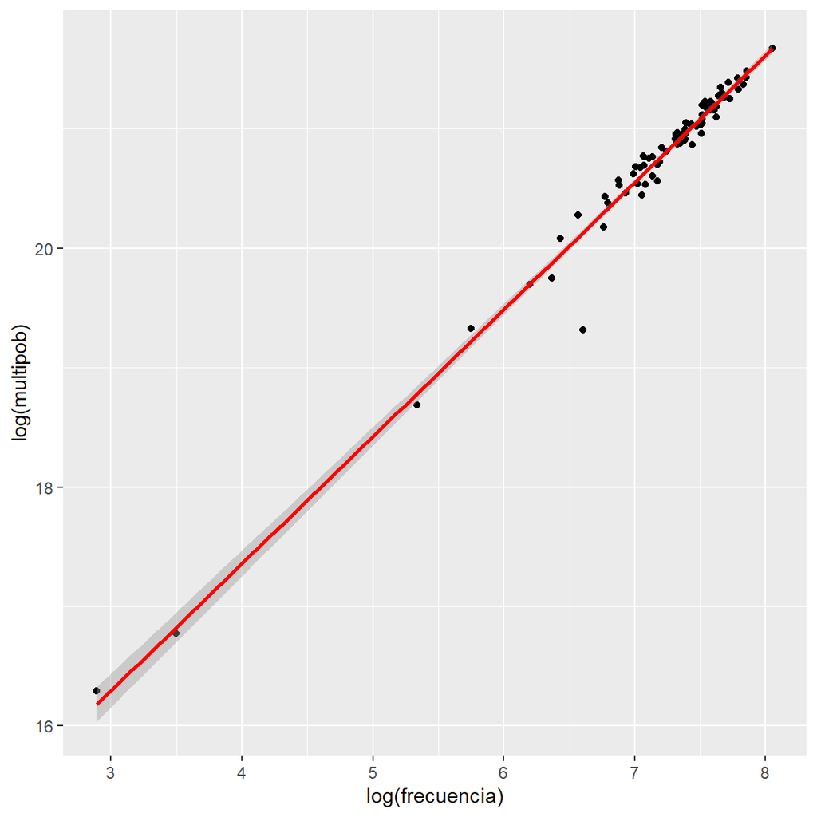

```r
ggplot(frec_sin, aes(x = log(frecuencia) , y = log(multipob))) + geom_point() + stat_smooth(method = "lm", col = "red")
```

#### 4.1.3.2 Análisis de residuos

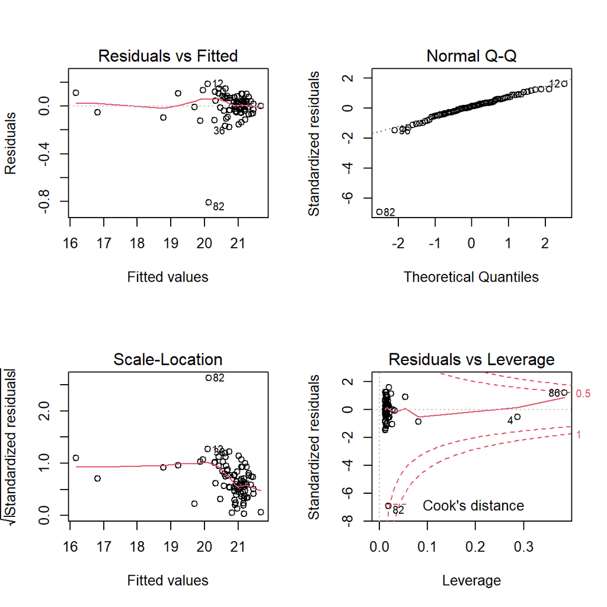

```r
par(mfrow = c (2,2))
plot(linearMod)
```

#### 4.1.3.3 Modelo log-log

$$\hat Y = e^{\beta_0+\beta_1 ln{X}}$$

#### 4.1.3.4 Modelo real:

$$\hat Y = e^{13.10277 + 1.06412 \cdot ln{X}}$$

```r
linearMod <- lm( log(multipob)~log(frecuencia) , data=frec_sin)
aa <- linearMod$coefficients[1]
bb <- linearMod$coefficients[2]
aa
```

```
## (Intercept)
##    13.10277
```

```r
bb
```

```
## log(frecuencia)
##        1.064123
```

# 5 Dos modelos

En nuestro trabajo sobre al área urbana nos encontramos sólo con dos modelos óptimos: todos son log-log a excepción del raíz-raíz que se utiliza en la región 15.

## 5.1 Modelo log-log

$$\hat Y = e^{\beta_0+\beta_1 ln{X}}$$

```r
head(frec_sin,10)
```

```
##          zona código.x P17 frecuencia  comuna   tipo promedio_i  año personas
## 1  1101011001    01101   1       1255 Iquique Urbano   356487.6 2017   191468
## 2  1101011002    01101   1        621 Iquique Urbano   356487.6 2017   191468
## 3  1101021001    01101   1        493 Iquique Urbano   356487.6 2017   191468
## 4  1101021002    01101   1         33 Iquique Urbano   356487.6 2017   191468
## 5  1101021003    01101   1       1224 Iquique Urbano   356487.6 2017   191468
## 6  1101021004    01101   1        968 Iquique Urbano   356487.6 2017   191468
## 7  1101021005    01101   1       1927 Iquique Urbano   356487.6 2017   191468
## 8  1101031001    01101   1       1179 Iquique Urbano   356487.6 2017   191468
## 9  1101031002    01101   1       1582 Iquique Urbano   356487.6 2017   191468
## 10 1101031003    01101   1       2111 Iquique Urbano   356487.6 2017   191468
##    Ingresos_expandidos            p   multipob
## 1          68255976664 0.0130100069  888010727
## 2          68255976664 0.0077036372  525819278
## 3          68255976664 0.0052384733  357557109
## 4          68255976664 0.0002820315   19250333
## 5          68255976664 0.0151200201 1032031736
## 6          68255976664 0.0125242860  854857376
## 7          68255976664 0.0236331920 1613106600
## 8          68255976664 0.0142321432  971428836
## 9          68255976664 0.0185618485 1266957095
## 10         68255976664 0.0273988343 1870134193
```

```r
frec_sin$est_ing <- exp(aa+ bb*log(frec_sin$frecuencia))
```

## 5.2 Modelo raíz-raíz

$$\hat Y = {\beta_0}^2 + 2 \beta_0 \beta_1 \sqrt{X}+ \beta_1^2 X$$

```r
# solo para la region 15
# tabla_5$est_ing <- aa^2+2*aa*bb*sqrt(tabla_5$frecuencia) + bb^2*tabla_5$frecuencia
```

# 6 Aplicación la regresión a los valores de la variable a nivel de zona

La variable estimada se llamará: **est_ing**

```r
head(frec_sin,10)
```

```
##          zona código.x P17 frecuencia  comuna   tipo promedio_i  año personas
## 1  1101011001    01101   1       1255 Iquique Urbano   356487.6 2017   191468
## 2  1101011002    01101   1        621 Iquique Urbano   356487.6 2017   191468
## 3  1101021001    01101   1        493 Iquique Urbano   356487.6 2017   191468
## 4  1101021002    01101   1         33 Iquique Urbano   356487.6 2017   191468
## 5  1101021003    01101   1       1224 Iquique Urbano   356487.6 2017   191468
## 6  1101021004    01101   1        968 Iquique Urbano   356487.6 2017   191468
## 7  1101021005    01101   1       1927 Iquique Urbano   356487.6 2017   191468
## 8  1101031001    01101   1       1179 Iquique Urbano   356487.6 2017   191468
## 9  1101031002    01101   1       1582 Iquique Urbano   356487.6 2017   191468
## 10 1101031003    01101   1       2111 Iquique Urbano   356487.6 2017   191468
##    Ingresos_expandidos            p   multipob    est_ing
## 1          68255976664 0.0130100069  888010727  972289284
## 2          68255976664 0.0077036372  525819278  459886409
## 3          68255976664 0.0052384733  357557109  359731066
## 4          68255976664 0.0002820315   19250333   20246207
## 5          68255976664 0.0151200201 1032031736  946752960
## 6          68255976664 0.0125242860  854857376  737557917
## 7          68255976664 0.0236331920 1613106600 1534530600
## 8          68255976664 0.0142321432  971428836  909758113
## 9          68255976664 0.0185618485 1266957095 1243960523
## 10         68255976664 0.0273988343 1870134193 1690914875
```

# 7 División del valor estimado entre la población total de la zona para obtener el ingreso medio por zona

$$Ingreso \_ Medio\_zona = est\_ing / (personas * p\_poblacional)$$

```r
frec_sin$ing_medio_zona <- as.numeric(frec_sin$est_ing /(frec_sin$personas  * frec_sin$p))
nrow(frec_sin)
```

```
## [1] 84
```

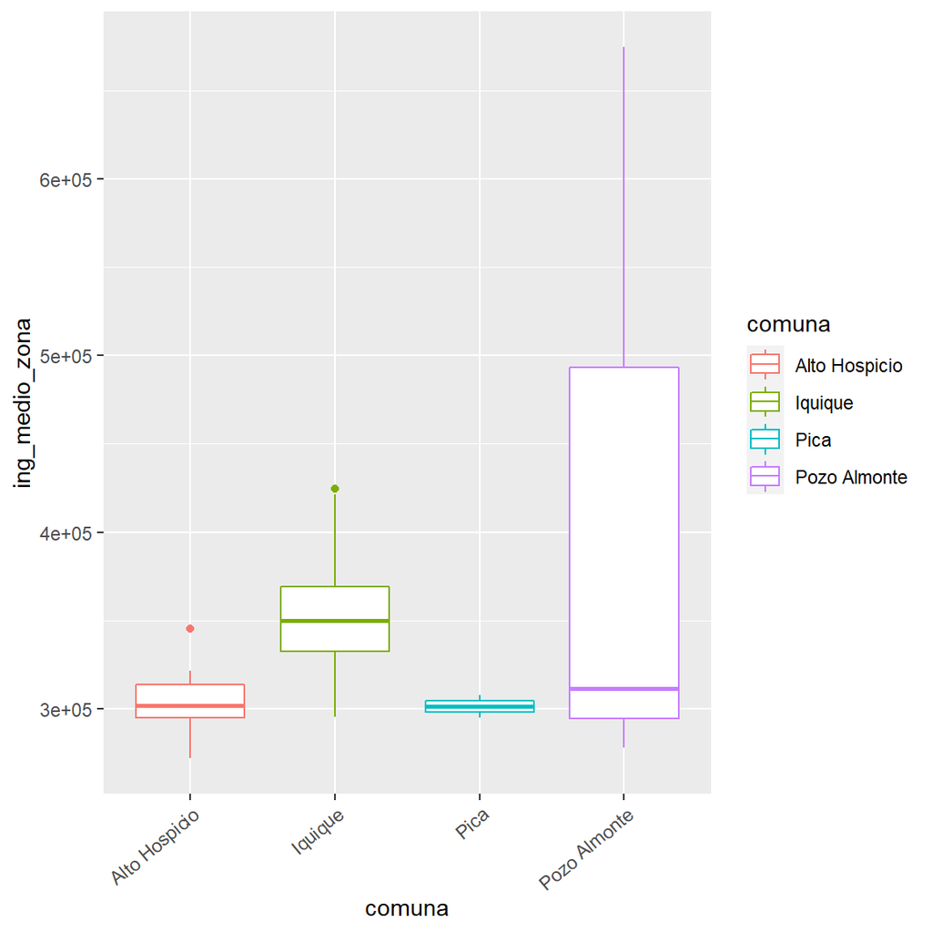

```r
pp <- ggplot(data = frec_sin) + geom_boxplot(aes(x=comuna, y=ing_medio_zona, color=comuna))
pp + theme(axis.text.x = element_text(angle = 40, vjust = 1, hjust=1))
```

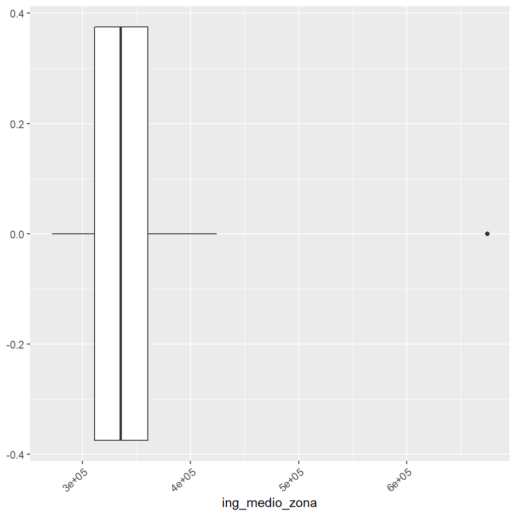

```r
pp <- ggplot(data = frec_sin) + geom_boxplot(aes(ing_medio_zona))
pp + theme(axis.text.x = element_text(angle = 40, vjust = 1, hjust=1))
```

```r
nrow(frec_sin)
```

```
## [1] 84
```

```r
yyy <- frec_sin$zona
```

# 8 Análisis de regresión SIN OUTLIERS

## 8.1 Criterio para excluir outliers de frecuencias:

```r
Q <- quantile(frec_sin$frecuencia, probs=c(.25, .75), na.rm = T)
iqr <- IQR(frec_sin$frecuencia, na.rm = T)
casen_2017_sin_o <- subset(frec_sin, frec_sin$frecuencia > (Q[1] - 1.5*iqr) & frec_sin$frecuencia < (Q[2]+1.5*iqr))
casen_2017_sin_o <- data.frame(lapply(casen_2017_sin_o, as.character), stringsAsFactors=FALSE)
# head(casen_2017_sin_o,10)
```

```r
nrow(casen_2017_sin_o)
```

```
## [1] 83
```

```r
xxx <- casen_2017_sin_o$zona
```

```r
print(setdiff(yyy,xxx))
```

```
## [1] "1107011003"
```

**3** Perdemos un registro, con lo que hay problemas de exclusión con el Error III.

```r
casen_2017_sin_o$frecuencia <- as.numeric(casen_2017_sin_o$frecuencia)
casen_2017_sin_o$promedio_i <- as.numeric(casen_2017_sin_o$promedio_i)
casen_2017_sin_o$Ingresos_expandidos <- as.numeric(casen_2017_sin_o$Ingresos_expandidos)
casen_2017_sin_o$multipob <- as.numeric(casen_2017_sin_o$multipob)
casen_2017_sin_o$est_ing <- as.numeric(casen_2017_sin_o$est_ing)
casen_2017_sin_o$ing_medio_zona <- as.numeric(casen_2017_sin_o$ing_medio_zona)
casen_2017_sin_o$personas <- as.numeric(casen_2017_sin_o$personas)
casen_2017_sin_o$p <- as.numeric(casen_2017_sin_o$p)
```

```r
# setdiff(casen_2017_sin_o,frec_sin )
```

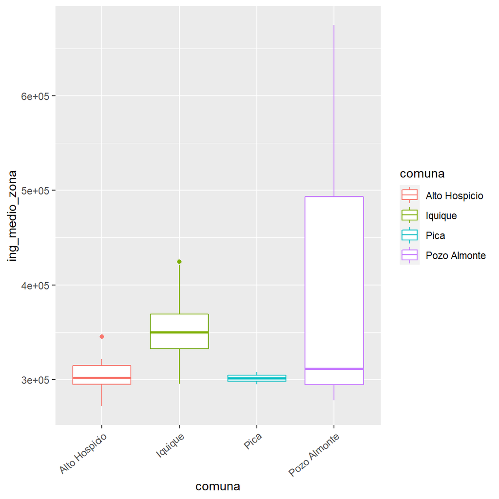

```r
pp <- ggplot(data = casen_2017_sin_o) + geom_boxplot(aes(x=comuna, y=ing_medio_zona, color=comuna))
pp + theme(axis.text.x = element_text(angle = 40, vjust = 1, hjust=1))
```

## 8.2 Criterio para excluir outliers de ing_medio_zona:

```r
casen_2017_sin_o2 <- casen_2017_sin_o
casen_2017_sin_o2$ing_medio_zona <- as.numeric(casen_2017_sin_o$ing_medio_zona)
Q <- quantile(casen_2017_sin_o2$ing_medio_zona, probs=c(.1, .9), na.rm = T)
iqr <- IQR(casen_2017_sin_o2$ing_medio_zona, na.rm = T)
casen_2017_sin_o2 <- subset(casen_2017_sin_o2, casen_2017_sin_o2$ing_medio_zona > (Q[1] - 1.5*iqr) & casen_2017_sin_o2$ing_medio_zona < (Q[2]+1.5*iqr))
casen_2017_sin_o2 <- data.frame(lapply(casen_2017_sin_o2, as.character), stringsAsFactors=FALSE)
casen_2017_sin_o2$multipob <- as.numeric(casen_2017_sin_o2$multipob)
casen_2017_sin_o2$frecuencia <- as.numeric(casen_2017_sin_o2$frecuencia)
casen_2017_sin_o2$ing_medio_zona <- as.numeric(casen_2017_sin_o2$ing_medio_zona)
# head(casen_2017_sin_o,10)
```

```r
nrow(casen_2017_sin_o2)
```

```
## [1] 82
```

**4** Perdemos un registro, con lo que hay problemas de exclusión con el Error IV.

Identifiquemoslo:

```r
yyy <- casen_2017_sin_o$zona
xxx <- casen_2017_sin_o2$zona
print(setdiff(yyy,xxx))
```

```
## [1] "1401991999"
```

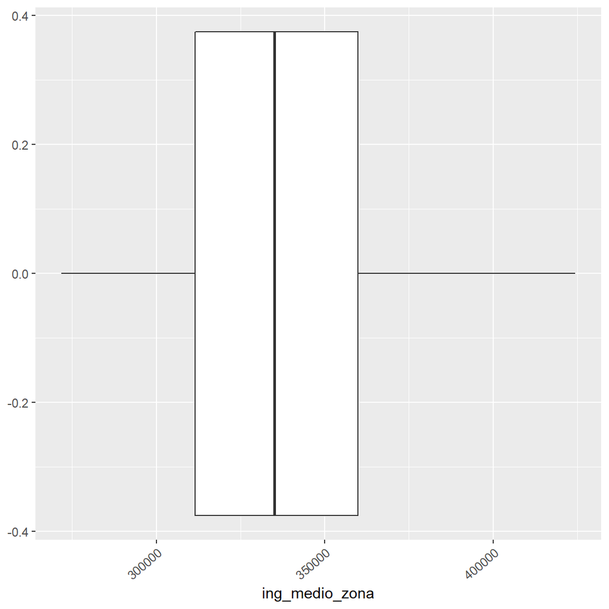

```r
pp <- ggplot(data = casen_2017_sin_o2) + geom_boxplot(aes(ing_medio_zona))
pp + theme(axis.text.x = element_text(angle = 40, vjust = 1, hjust=1))
```

```r
casen_2017_sin_o$razon_de_exclusion <- "ninguno"
```

# 9 Tabla Región 01 final

Añadimos los excluídos con su razón de exclusión:

1404011001 no existe dato Casen

1404991999 no existe dato Casen

1107011003 outlier frecuencias

1401991999 outlier ingreso medio

```r
z1<-data.frame(zona=c(1404011001),
              código.x = c(0),
              P17= c(0),
              frecuencia= c(0),
              comuna= c(0),
              tipo= c(0),
              promedio_i= c(0),
              año= c(0),
              personas= c(0),
              Ingresos_expandidos= c(0),
              p= c(0),
              multipob= c(0),
              est_ing= c(0),
              ing_medio_zona= c(0),
              razon_de_exclusion=c("no existe dato Casen"))

z2<-data.frame(zona=c(1404991999),
              código.x = c(0),
              P17= c(0),
              frecuencia= c(0),
              comuna= c(0),
              tipo= c(0),
              promedio_i= c(0),
              año= c(0),
              personas= c(0),
              Ingresos_expandidos= c(0),
              p= c(0),
              multipob= c(0),
              est_ing= c(0),
              ing_medio_zona= c(0),
              razon_de_exclusion=c("no existe dato Casen"))

z3<-data.frame(zona=c(1107011003),
              código.x = c(0),
              P17= c(0),
              frecuencia= c(0),
              comuna= c(0),
              tipo= c(0),
              promedio_i= c(0),
              año= c(0),
              personas= c(0),
              Ingresos_expandidos= c(0),
              p= c(0),
              multipob= c(0),
              est_ing= c(0),
              ing_medio_zona= c(0),
              razon_de_exclusion=c("outlier frecuencias"))

z4<-data.frame(zona=c(1401991999),
              código.x = c(0),
              P17= c(0),
              frecuencia= c(0),
              comuna= c(0),
              tipo= c(0),
              promedio_i= c(0),
              año= c(0),
              personas= c(0),
              Ingresos_expandidos= c(0),
              p= c(0),
              multipob= c(0),
              est_ing= c(0),
              ing_medio_zona= c(0),
              razon_de_exclusion=c("outlier ingreso medio"))
```

```r
casen_2017_sin_o<-rbind(casen_2017_sin_o,z1)
casen_2017_sin_o<-rbind(casen_2017_sin_o,z2)
casen_2017_sin_o<-rbind(casen_2017_sin_o,z3)
casen_2017_sin_o<-rbind(casen_2017_sin_o,z4)
```

```r
saveRDS(casen_2017_sin_o, "urbanidad/region_01_P17_u_final.rds")
write_xlsx(casen_2017_sin_o, "urbanidad/region_01_P17_u_final.xlsx")
```

# 10 Referencias

https://rpubs.com/osoramirez/316691

https://dataintelligencechile.shinyapps.io/casenfinal

Manual_de_usuario_Censo_2017_16R.pdf

http://www.censo2017.cl/microdatos/

Censo de Población y Vivienda

https://www.ine.cl/estadisticas/sociales/censos-de-poblacion-y-vivienda/poblacion-y-vivienda

http://r-statistics.co/Linear-Regression.html

# 11 Anexo:

## 11.1 Modelos alternativos

### 11.1.1 Modelo cuadrático

$$\hat Y = \beta_0 + \beta_1 X^2$$

### 11.1.2 Modelo cúbico

$$\hat Y = \beta_0 + \beta_1 X^3$$

### 11.1.3 Modelo logarítmico

$$\hat Y = \beta_0 + \beta_1 ln X$$

### 11.1.4 Modelo exponencial

$$\hat Y = \beta_0 + \beta_1 e^X$$

No es aplicable sin una transformación pues los valores elevados a $e$ de Freq.x tienden a infinito.

### 11.1.5 Modelo con raíz cuadrada

$$\hat Y = \beta_0 + \beta_1 \sqrt {X}$$

### 11.1.6 raiz raiz

$$\hat Y = {\beta_0}^2 + 2 \beta_0 \beta_1 \sqrt{X}+ \beta_1^2 X$$

### 11.1.7 Modelo log-raíz

$$\hat Y = e^{\beta_0 + \beta_1 \sqrt{X}}$$

### 11.1.8 Modelo raíz-log

$$\hat Y = {\beta_0}^2 + 2 \beta_0 \beta_1 \ln{X}+ \beta_1^2 ln^2X$$

### 11.1.9 Modelo log-log

$$\hat Y = e^{\beta_0+\beta_1 ln{X}}$$

https://www.investopedia.com/terms/e/empirical-rule.asp

```r
# archivos <- dir("urbanidad/", pattern = "*.rds")
# unadataframe <- data.frame()
# for(i in archivos ){
#   tablilla <- paste0('urbanidad/',i)
#   region <- readRDS(tablilla)
#   unadataframe = rbind( unadataframe, region )
# }
# saveRDS(unadataframe, "urbanidad/nacional_P17_u_nuevo.rds")
```